# Loan Data from Prosper

By Mohamed Safwan

## Dataset Overview

Prosper was founded in 2005 as the first peer-to-peer lending marketplace in the United States. Since then, Prosper has facilitated loans to more than 870,000 people.

## Investigation Overview

- Does Prosper give loan based on employment status?
- Does Prosper give out with income as part of their consideration?
- What is the most common occupation of the borrowers?
- what is the borrower's APR for people who has a loan?
- What are factors which can affect the borrower's rate?
- What is the yearly borrower rates?
- Does yearly prosper Score or homeowner affect borrower's rate?

## Employment Status

The employment status of the borrower at the time they posted the listing.

Does Prosper give loan based on employment status?

- The plot shows that unemployed , part time and retired individuals can rarely obtain a loan from Prosper.
- It is most common that employed and full time individuals obtain a loan from Porsper.

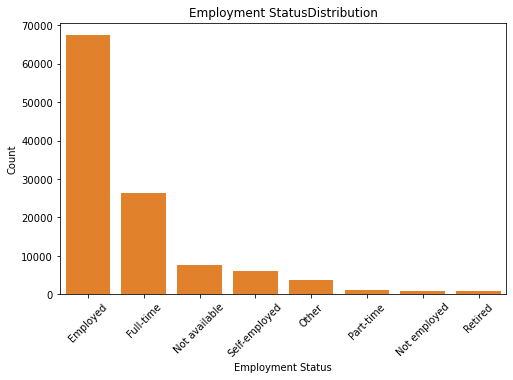

## Borrower Rate

The Borrower's interest rate for the loan.

What is the borrower's APR for people who has a loan?

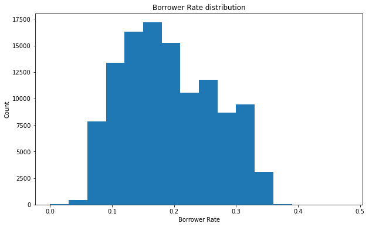

## Borrower Rate vs. Employment status

I want to find out the relationship between the borrower's rate and the employment status.  
Does Prosper determine the rate based on employment status?

Individual who is employed don't necessarily have low borrower rate.  
Unemployment individual has a high median rate and high concentrate frequency above the median.

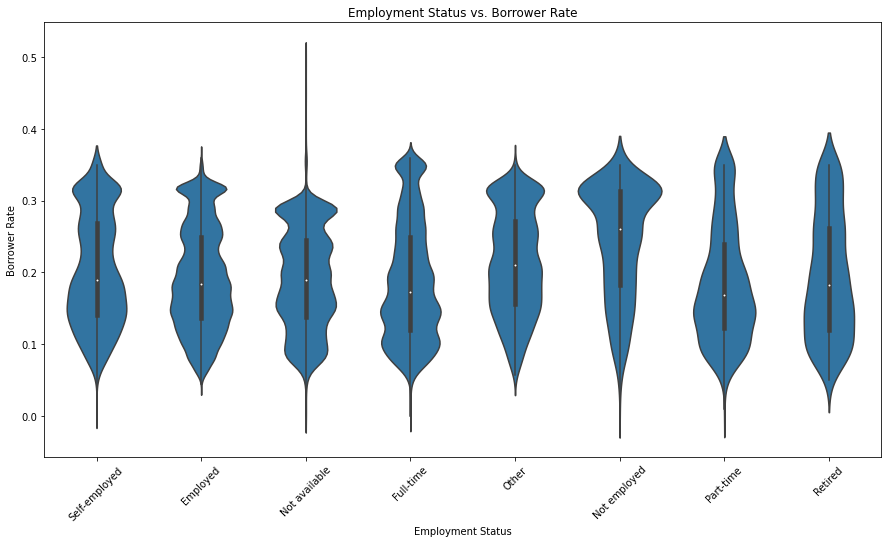

## Yearly Borrower Rates

What is the yearly borrower rates?  
Does the borrow rate increase by time?

The plot shows that:

- The year 2005 represents the minimum average borrower rate.
- Borrower rate goes up after 2008 until 2011.
- Since 2011, the rate started going down until 2014.

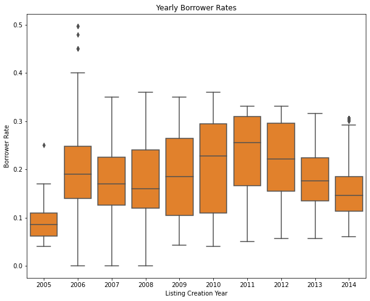

## Borrower rates vs. Prosper Score

Is Prosper Score considered an factor to determine the borrower rate?

This plot shows that:

- There is a strong correlation between the prosper score with the borrower rate.
- The higher the prosper score is, the lower the borrower rate is.
- The prosper score is a an important factor to determinate the borrower rate.

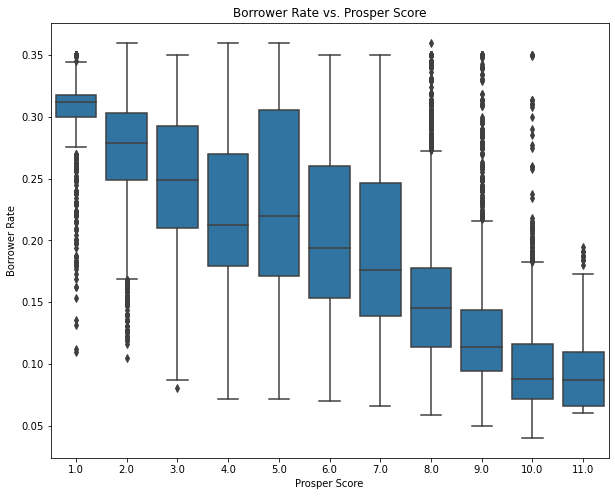

## Yearly Borrower rate vs. Home-owner

Does being a homeowner affect borrower rate?

The plot shows that homeowners always have alower rate than non-homeowners.

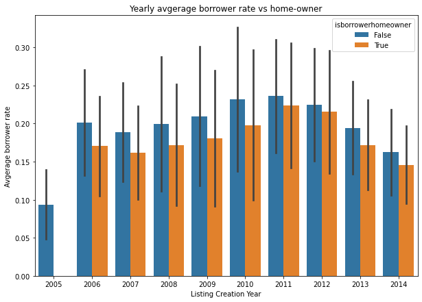

### Year Borrower Rate vs. Prosper Score vs. Is_HomeOwner

Does yearly prosper Score and homeowner affect borrower's rate?

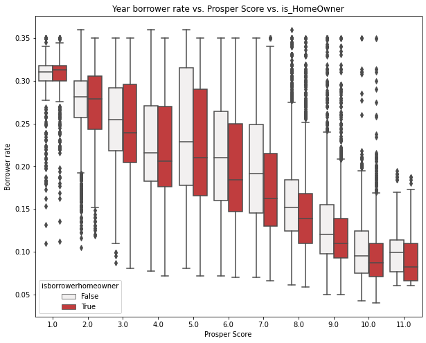

[output not shown]